# FY2022 Analysis - Methodology for Fiscal Futures

# Graphs

Graphs made from `aggregated_totals_long` dataframe.

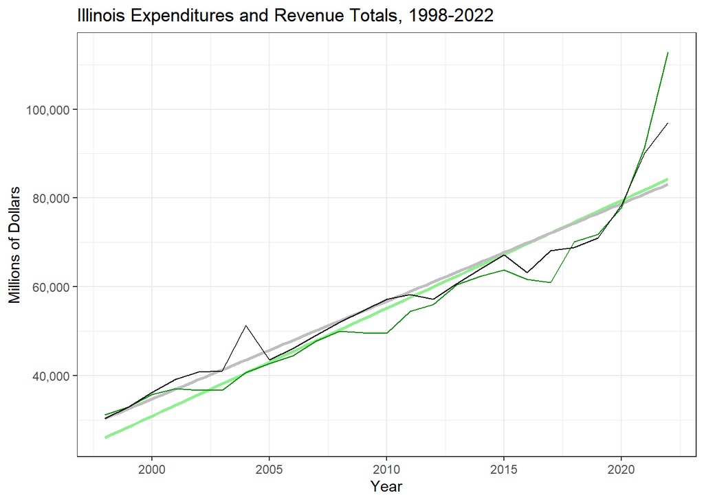

```r
year_totals %>%
  ggplot() +
  # geom_smooth adds regression line, graphed first so it appears behind line graph
  geom_smooth(aes(x = Year, y = Revenue), color = "light green", method = "lm", se = FALSE) +
  geom_smooth(aes(x = Year, y = Expenditures), color = "gray", method = "lm", se = FALSE) +

  # line graph of revenue and expenditures
  geom_line(aes(x = Year, y = Revenue), color = "green4") +
  geom_line(aes(x = Year, y = Expenditures), color = "black") +

  # labels
    theme_bw() +
  scale_y_continuous(labels = comma)+
  xlab("Year") +
  ylab("Millions of Dollars")  +
  ggtitle("Illinois Expenditures and Revenue Totals, 1998-2022")
```

**Expenditure and revenue amounts in millions of dollars:**

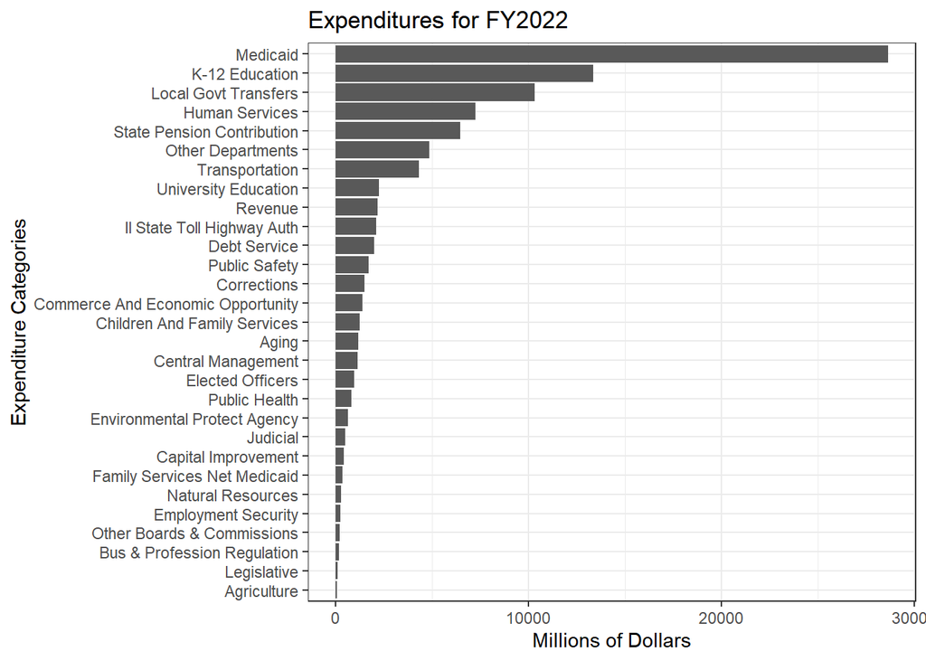

```r
exp_long %>%
  filter(Year == 2022) %>%
  #mutate(`Total Expenditures`= sum(Dollars, na.rm = TRUE)) %>%
 # select(-c(Year, `Total Expenditures`)) %>%
  arrange(desc(`Dollars`)) %>%
  ggplot() +
  geom_col(aes(x = fct_reorder(Category_name, `Dollars`), y = `Dollars`))+
  coord_flip() +
      theme_bw() +
  labs(title = "Expenditures for FY2022") +
    xlab("Expenditure Categories") +
  ylab("Millions of Dollars")
```

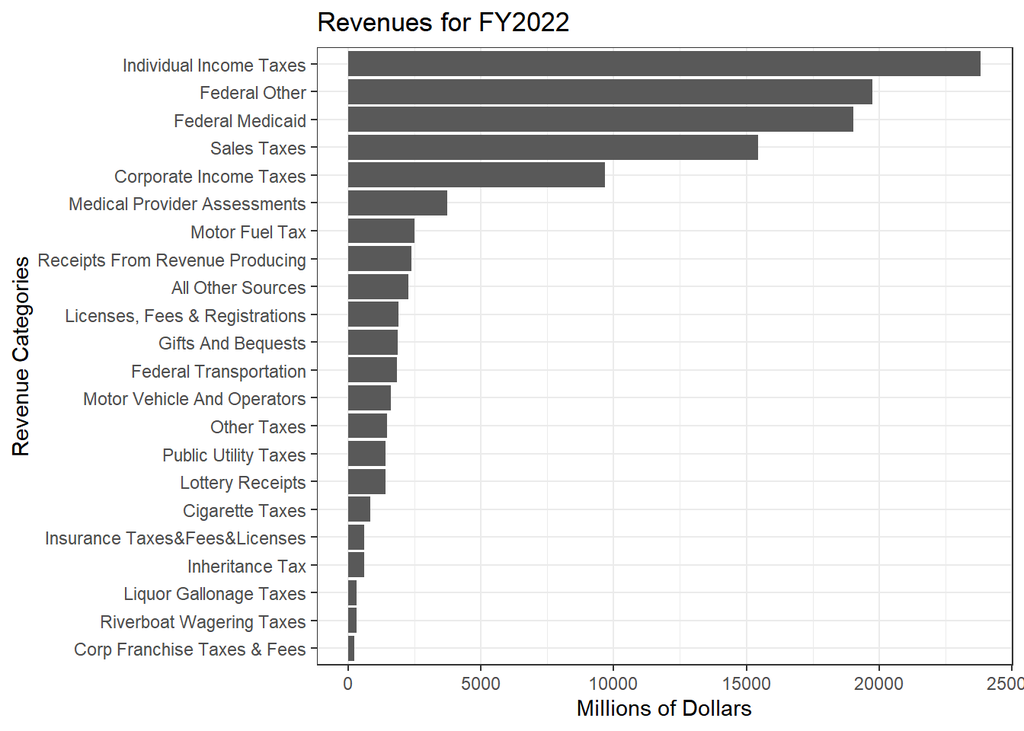

```r
rev_long %>%
  filter(Year == 2022) %>%
  #mutate(`Total Expenditures`= sum(Dollars, na.rm = TRUE)) %>%
 # select(-c(Year, `Total Expenditures`)) %>%
  arrange(desc(`Dollars`)) %>%
  ggplot() +
  geom_col(aes(x = fct_reorder(Category_name, `Dollars`), y = `Dollars`))+
  coord_flip() +
    theme_bw() +
      labs(title = "Revenues for FY2022")+
    xlab("Revenue Categories") +
  ylab("Millions of Dollars")
```

**Expenditure and revenues when focusing on largest categories and combining others into “All Other Expenditures(Revenues)”:**

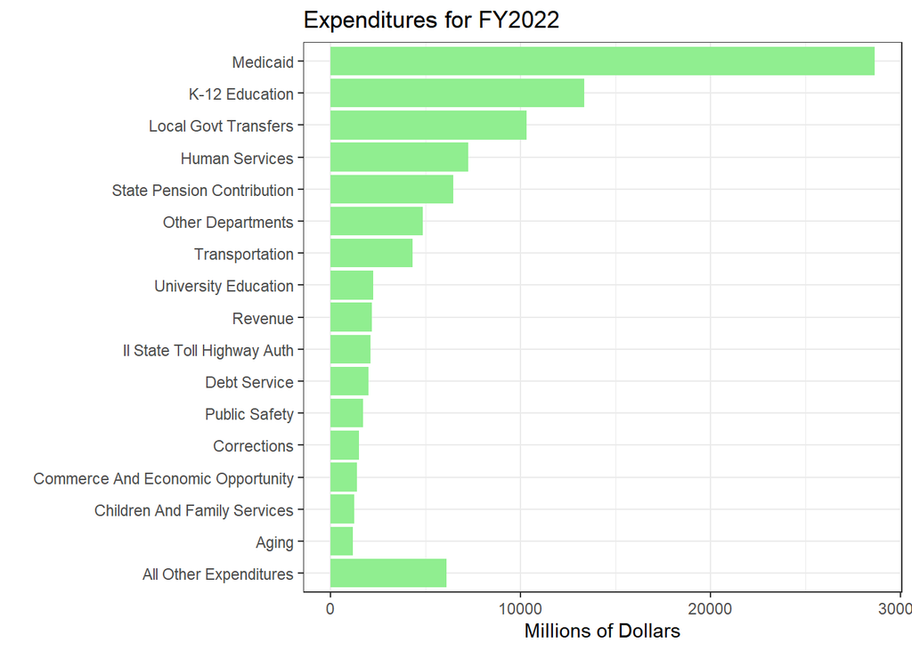

```r
exp_long %>%
  filter( Year == 2022) %>%
  mutate(rank = rank(Dollars),
        Category_name = ifelse(rank > 13, Category_name, 'All Other Expenditures')) %>%
 # select(-c(Year, Dollars, rank)) %>%
  arrange(desc(Dollars)) %>%
  ggplot() +
  geom_col(aes(x = fct_reorder(Category_name, `Dollars`), y = `Dollars`), fill = "light green")+
  coord_flip() +
      theme_bw() +
    labs(title = "Expenditures for FY2022") +
    xlab("") +
  ylab("Millions of Dollars")
```

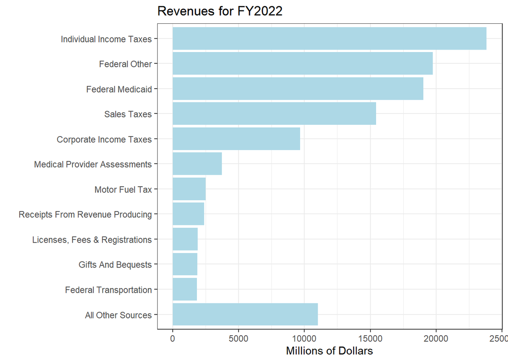

```r
rev_long %>%
  filter( Year == 2022) %>%
  mutate(rank = rank(Dollars),
        Category_name = ifelse(rank > 10, Category_name, 'All Other Sources')) %>%
  arrange(desc(Dollars)) %>%
  ggplot() +
  geom_col(aes(x = fct_reorder(Category_name, `Dollars`), y = `Dollars`), fill = "light blue")+
  coord_flip() +
      theme_bw() +
    labs(title = "Revenues for FY2022") +
    xlab("") +
  ylab("Millions of Dollars")
```

**Changes in Categories - 2021 to 2022** Dot Plot Attempt:

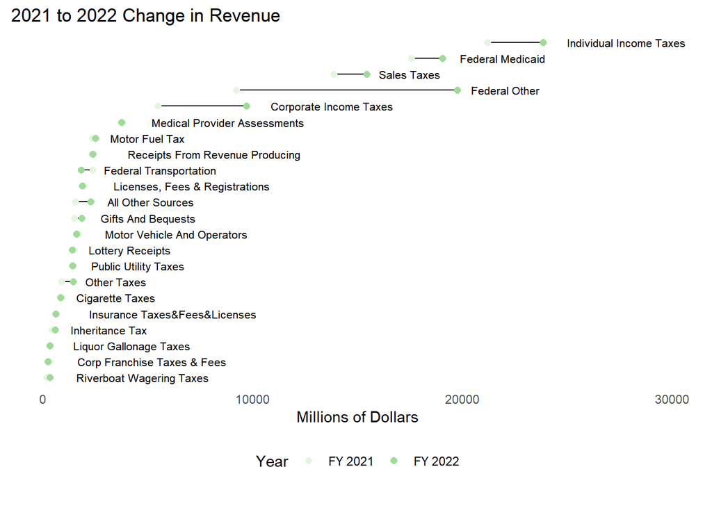

```r
rev_long %>%
    filter(Year == "2022" | Year == "2021") %>%
  mutate(Year = as.character(Year)) %>%
  ggplot(aes(x = Dollars, y = reorder(Category, Dollars))) +
  geom_line(aes(group = Category) )+
    geom_text(aes(x = ifelse(Year == "2022", as.numeric(Dollars), NA),  label = ifelse(Year == "2022", Category_name, "")),
            hjust = -0.2,
            size = 2.8) +
         geom_point(aes(color = Year), size=2)  +
  labs(title = "2021 to 2022 Change in Revenue", x = "Millions of Dollars" , y = "",  caption = "")  +
   scale_color_brewer(palette = "paired", labels = c("FY 2021", "FY 2022"))+
   theme_classic()+
    theme(
   legend.position = "bottom" ,
  axis.text.y = element_blank(),
  axis.ticks.y = element_blank(),
  axis.line.y.left  = element_blank(),
  axis.line.x = element_blank(),
    axis.title.y = element_blank(),
  axis.ticks.x = element_blank())+
  scale_x_continuous(limits = c(0, 30000))
```

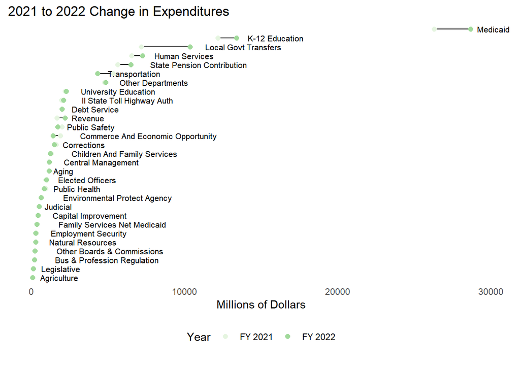

```r
exp_long %>%
    filter(Year == "2022" | Year == "2021") %>%
  mutate(Year = as.character(Year)) %>%
  ggplot(aes(x = Dollars, y = reorder(Category, Dollars))) +
  geom_line(aes(group = Category) )+
    geom_text(aes(x = ifelse(Year == "2022", as.numeric(Dollars), NA),  label = ifelse(Year == "2022", Category_name, "")),
            hjust = -0.2,
            size = 2.8) +
         geom_point(aes(color = Year), size=2)  +
  labs(title = "2021 to 2022 Change in Expenditures", x = "Millions of Dollars" , y = "",  caption = "")  +
   scale_color_brewer(palette = "paired", labels = c("FY 2021", "FY 2022"))+
   theme_classic()+
    theme(
    legend.position = "bottom" ,
  axis.text.y = element_blank(),
  axis.ticks.y = element_blank(),
  axis.line.y.left  = element_blank(),
  axis.line.x = element_blank(),
    axis.title.y = element_blank(),
  axis.ticks.x = element_blank())+
  scale_x_continuous(limits = c(0, 30000))
```

# CAGR / Growth

Each year, you will need to update the CAGR formulas!

`calc_cagr` is a function created for calculating the CAGRs for different spans of time.

```r
# function for calculating the CAGR
calc_cagr <- function(df, n) {
  df <- exp_long %>%
    select(-type) %>%
    arrange(Category_name, Year) %>%
    group_by(Category_name) %>%
    mutate(cagr = ((`Dollars` / lag(`Dollars`, n)) ^ (1 / n)) - 1)

  return(df)
}

# This works for one variable at a time
cagr_24 <- calc_cagr(exp_long, 24) %>%
  # group_by(Category) %>%
  summarize(cagr_24 = round(sum(cagr*100, na.rm = TRUE), 2))

cagr23_precovid <- exp_long %>%
  filter(Year <= 2019) %>%
  calc_cagr(21) %>%
  summarize(cagr_21 = round(sum(cagr*100, na.rm = TRUE), 2))



cagr_10 <- calc_cagr(exp_long, 10) %>%
  filter(Year == 2022) %>%
  summarize(cagr_10 = case_when(Year == 2022 ~ round(sum(cagr*100, na.rm = TRUE), 2)))

cagr_5 <- calc_cagr(exp_long, 5) %>%
  filter(Year == 2022) %>%
  summarize(cagr_5 = case_when(Year == 2022 ~ round(sum(cagr*100, na.rm = TRUE), 2)))

cagr_3 <- calc_cagr(exp_long, 3) %>%
  filter(Year == 2022) %>%
  summarize(cagr_3 = case_when(Year == 2022 ~ round(sum(cagr*100, na.rm = TRUE), 2)))

cagr_2 <- calc_cagr(exp_long, 2) %>%
  filter(Year == 2022) %>%
  summarize(cagr_2 = case_when(Year == 2022 ~ round(sum(cagr*100, na.rm = TRUE), 2)))

cagr_1 <- calc_cagr(exp_long, 1) %>%
  filter(Year == 2022) %>%
  summarize(cagr_1 = case_when(Year == 2022 ~ round(sum(cagr*100, na.rm = TRUE), 2)))

CAGR_expenditures_summary <- data.frame(cagr_1, cagr_2, cagr_3, cagr_5, cagr_10, cagr_24 ) %>%
  select(-c(Category_name.1, Category_name.2, Category_name.3, Category_name.4, Category_name.5 )) %>%
  rename("Expenditure Category" = Category_name, "1 Year CAGR" = cagr_1, "2 Year CAGR" = cagr_2, "3 Year CAGR" = cagr_3, "5 Year CAGR" = cagr_5, "10 Year CAGR" = cagr_10,"24 Year CAGR" = cagr_24 )

CAGR_expenditures_summary %>%
  kbl(caption = "CAGR Calculations for Expenditure Categories") %>%
  kable_styling(bootstrap_options = c("striped"))
```

CAGR Calculations for Expenditure Categories

| Expenditure Category | 1 Year CAGR | 2 Year CAGR | 3 Year CAGR | 5 Year CAGR | 10 Year CAGR | 24 Year CAGR |
| --- | --- | --- | --- | --- | --- | --- |
| Aging | 2.69 | 5.01 | 5.94 | -1.34 | 3.97 | 7.33 |
| Agriculture | 33.46 | 11.29 | 5.58 | 5.10 | 2.49 | 0.81 |
| Bus & Profession Regulation | 8.30 | 5.18 | 3.21 | 1.93 | -1.82 | 1.20 |
| Capital Improvement | -6.65 | 17.25 | 18.16 | 10.70 | -3.67 | 2.13 |
| Central Management | -2.75 | 6.11 | 11.99 | 2.62 | 4.45 | 5.02 |
| Children And Family Services | -3.90 | 0.55 | 2.79 | 3.08 | 0.51 | -0.16 |
| Commerce And Economic Opportunity | -25.67 | 50.78 | 34.76 | 16.78 | 3.23 | 4.74 |
| Corrections | -6.79 | -1.13 | -1.69 | 3.33 | 1.62 | 1.77 |
| Debt Service | -0.83 | 1.59 | -0.70 | 1.65 | 1.19 | 6.11 |
| Elected Officers | 3.50 | 5.26 | 2.24 | 6.05 | 3.93 | 3.71 |
| Employment Security | -16.09 | 7.77 | 7.46 | 7.21 | 1.28 | 1.97 |
| Environmental Protect Agency | -3.19 | -4.83 | -8.21 | -6.78 | 0.02 | 3.13 |
| Family Services Net Medicaid | -4.49 | 3.24 | -9.40 | -0.54 | 0.02 | 4.89 |
| Human Services | 11.13 | 10.16 | 8.99 | 6.13 | 3.29 | 2.59 |
| Il State Toll Highway Auth | 7.06 | 4.69 | 6.28 | 3.57 | 11.64 | 7.54 |
| Judicial | -2.35 | 3.00 | 6.80 | 3.75 | 2.73 | 2.71 |
| K-12 Education | 9.87 | 8.79 | 7.95 | 6.51 | 4.10 | 4.13 |
| Legislative | 19.67 | 11.90 | 10.76 | 7.37 | 2.38 | 3.19 |
| Local Govt Transfers | 44.14 | 26.60 | 16.64 | 9.88 | 6.39 | 4.65 |
| Medicaid | 9.04 | 13.38 | 14.62 | 9.92 | 8.89 | 7.20 |
| Natural Resources | 0.04 | 2.04 | 0.87 | 4.71 | 2.58 | 1.53 |
| Other Boards & Commissions | -1.11 | 7.87 | 2.28 | 2.41 | -3.01 | 4.01 |
| Other Departments | 1.58 | 4.66 | 8.10 | 5.57 | 7.03 | 9.09 |
| Public Health | -11.21 | 22.41 | 24.37 | 17.68 | 7.48 | 7.11 |
| Public Safety | -14.29 | 7.54 | 19.41 | 15.88 | 8.11 | 5.89 |
| Revenue | 31.53 | 40.11 | 54.86 | 35.46 | 16.10 | 7.15 |
| State Pension Contribution | 15.42 | 10.80 | 9.67 | 9.26 | 9.38 | 10.76 |
| Transportation | -18.99 | 2.92 | 7.85 | 0.68 | -0.32 | 3.31 |
| University Education | 2.72 | 1.46 | 3.25 | -1.08 | -0.94 | 0.36 |

```r
# to have it as a csv, uncomment the line below
#write_csv(CAGR_expenditures_summary, "CAGR_expenditures_summary.csv")
```

```r
calc_cagr <- function(df, n) {
  df <- rev_long %>%
    arrange(Category_name, Year) %>%
    group_by(Category_name) %>%
    mutate(cagr = ((Dollars / lag(Dollars, n)) ^ (1 / n)) - 1)

  return(df)
}

# This works for one variable at a time
cagr_24 <- calc_cagr(rev_long, 24) %>%
     # group_by(Category) %>%
  summarize(cagr_24 = round(sum(cagr*100, na.rm = TRUE), 2))

cagr_10 <- calc_cagr(rev_long, 10) %>%
  filter(Year == 2022) %>%
  summarize(cagr_10 = case_when(Year == 2022 ~ round(sum(cagr*100, na.rm = TRUE), 2)))

cagr_5 <- calc_cagr(rev_long, 5) %>%
  filter(Year == 2022) %>%
  summarize(cagr_5 = case_when(Year == 2022 ~ round(sum(cagr*100, na.rm = TRUE), 2)))

cagr_3 <- calc_cagr(rev_long, 3) %>%
  filter(Year == 2022) %>%
  summarize(cagr_3 = case_when(Year == 2022 ~ round(sum(cagr*100, na.rm = TRUE), 2)))

cagr_2 <- calc_cagr(rev_long, 2) %>%
  filter(Year == 2022) %>%
  summarize(cagr_2 = case_when(Year == 2022 ~ round(sum(cagr*100, na.rm = TRUE), 2)))

 cagr_1 <- calc_cagr(rev_long, 1) %>%
  filter(Year == 2022) %>%
  summarize(cagr_1 = case_when(Year == 2022 ~ round(sum(cagr*100, na.rm = TRUE), 2)))

CAGR_revenue_summary <- data.frame(cagr_1, cagr_2, cagr_3, cagr_5, cagr_10, cagr_24) %>%
  select(-c(Category_name.1, Category_name.2, Category_name.3, Category_name.4, Category_name.5 )) %>%
  rename("Revenue Category" = Category_name, "1 Year CAGR" = cagr_1, "2 Year CAGR" = cagr_2, "3 Year CAGR" = cagr_3, "5 Year CAGR" = cagr_5, "10 Year CAGR" = cagr_10,"24 Year CAGR" = cagr_24 )

CAGR_revenue_summary %>%
  kbl(caption = "CAGR Calculations for Revenue Sources") %>%
  kable_styling(bootstrap_options = c("striped"))
```

CAGR Calculations for Revenue Sources

| Revenue Category | 1 Year CAGR | 2 Year CAGR | 3 Year CAGR | 5 Year CAGR | 10 Year CAGR | 24 Year CAGR |
| --- | --- | --- | --- | --- | --- | --- |
| All Other Sources | 46.48 | 13.20 | 14.88 | 8.83 | 6.61 | 4.38 |
| Cigarette Taxes | -8.25 | -0.54 | 3.02 | 1.49 | 3.33 | 2.51 |
| Corp Franchise Taxes & Fees | -32.40 | 1.21 | -4.37 | 0.85 | 1.18 | 2.55 |
| Corporate Income Taxes | 76.66 | 72.77 | 38.19 | 32.31 | 13.59 | 7.70 |
| Federal Medicaid | 8.48 | 17.30 | 16.43 | 12.76 | 11.30 | 7.52 |
| Federal Other | 114.47 | 42.66 | 49.24 | 27.19 | 11.91 | 7.17 |
| Federal Transportation | -22.95 | 1.39 | 10.40 | -2.73 | -0.06 | 3.33 |
| Gifts And Bequests | 23.76 | 42.11 | 18.49 | 10.46 | 10.65 | 11.43 |
| Individual Income Taxes | 12.60 | 16.35 | 9.25 | 15.22 | 5.36 | 5.68 |
| Inheritance Tax | 35.98 | 48.20 | 16.36 | 18.47 | 10.12 | 3.74 |
| Insurance Taxes&Fees&Licenses | -3.42 | 12.76 | 5.20 | 2.79 | 3.20 | 6.56 |
| Licenses, Fees & Registrations | -4.68 | 15.06 | 16.83 | 9.26 | 6.23 | 7.87 |
| Liquor Gallonage Taxes | 2.53 | 2.81 | 2.49 | 1.69 | 1.37 | 7.45 |
| Lottery Receipts | -6.17 | 9.62 | 1.63 | 2.27 | 0.90 | 2.15 |
| Medical Provider Assessments | -1.98 | 3.67 | 16.26 | 11.80 | 8.33 | 8.36 |
| Motor Fuel Tax | 6.12 | 4.36 | 23.16 | 13.42 | 6.98 | 2.78 |
| Motor Vehicle And Operators | -5.59 | 4.66 | -0.04 | 0.15 | 0.64 | 3.21 |
| Other Taxes | 63.89 | 32.74 | 17.36 | 13.92 | 17.13 | 7.87 |
| Public Utility Taxes | 3.09 | -0.43 | -1.43 | 0.22 | -0.48 | 0.70 |
| Receipts From Revenue Producing | 3.01 | 4.78 | -2.68 | 1.45 | 3.49 | 5.07 |
| Riverboat Wagering Taxes | 80.77 | -1.03 | -8.90 | -6.18 | -4.20 | 1.75 |
| Sales Taxes | 11.29 | 12.22 | 7.40 | 6.27 | 4.43 | 3.23 |

```r
# to have it as a csv, uncomment the line below
#write_csv(CAGR_revenue_summary, "CAGR_revenue_summary.csv")

rm(cagr_1, cagr_2, cagr_3, cagr_5, cagr_10, cagr_24)
```

Expenditure and Revenue Growth using a lag formula:

```r
 exp_long %>%
  group_by(Category_name) %>%
  mutate(Growth = ((Dollars) - lag(Dollars))/lag(Dollars) *100) %>%
  summarize(Growth = round(mean(Growth, na.rm = TRUE), 2))
```

| Category_name | Growth |
| --- | --- |
| Aging | 9.05 |
| Agriculture | 1.73 |
| Bus & Profession Regulation | 1.85 |
| Capital Improvement | 15.90 |
| Central Management | 6.13 |
| Children And Family Services | -0.11 |
| Commerce And Economic Opportunity | 13.49 |
| Corrections | 2.87 |
| Debt Service | 6.95 |
| Elected Officers | 3.94 |

[output cut: 19 more lines]

```r
 rev_long %>%
  group_by(Category_name) %>%
  mutate(Growth = ((Dollars) - lag(Dollars))/lag(Dollars) *100) %>%
  summarize(Growth = round(mean(Growth, na.rm = TRUE), 2))
```

| Category_name | Growth |
| --- | --- |
| All Other Sources | 5.99 |
| Cigarette Taxes | 3.29 |
| Corp Franchise Taxes & Fees | 3.62 |
| Corporate Income Taxes | 11.15 |
| Federal Medicaid | 8.27 |
| Federal Other | 9.74 |
| Federal Transportation | 4.71 |
| Gifts And Bequests | 14.60 |
| Individual Income Taxes | 6.74 |
| Inheritance Tax | 8.18 |

[output cut: 12 more lines]

# Change from Previous Year

```r
revenue_change <- rev_long %>%
  select(-c(type,Category)) %>%
  filter(Year > 2020) %>%
  pivot_wider(names_from = Year , values_from = Dollars,   names_prefix = "Dollars_") %>%
  mutate(
    "FY 2022 Revenues ($ billions)" = round(Dollars_2022/1000, digits = 1),
#    "Change from 2021 to 2022" = round(Dollars_2022 - Dollars_2021, digits = 2),
         "Percent Change from 2021 to 2022" = round(((Dollars_2022 -Dollars_2021)/Dollars_2021*100), digits = 2)) %>%
  left_join(CAGR_revenue_summary, by = c("Category_name" = "Revenue Category")) %>%
    arrange(-`FY 2022 Revenues ($ billions)`)%>%
  #select(-c(Dollars_2021, Dollars_2021, `1 Year CAGR`:`10 Year CAGR`)) %>%
  rename( "Compound Annual Growth, 1998-2022*" = `24 Year CAGR`,
          "FY2022 Revenue Category" = Category_name ) %>%
  select(-c(Dollars_2021, Dollars_2022, `1 Year CAGR`:`10 Year CAGR`))

revenue_change %>%
  kbl(caption = "Yearly Change in Revenue") %>%
  kable_styling(bootstrap_options = c("striped"))
```

Yearly Change in Revenue

| FY2022 Revenue Category | FY 2022 Revenues ($ billions) | Percent Change from 2021 to 2022 | Compound Annual Growth, 1998-2022* |
| --- | --- | --- | --- |
| Individual Income Taxes | 23.8 | 12.60 | 5.68 |
| Federal Other | 19.8 | 114.47 | 7.17 |
| Federal Medicaid | 19.0 | 8.48 | 7.52 |
| Sales Taxes | 15.4 | 11.29 | 3.23 |
| Corporate Income Taxes | 9.7 | 76.66 | 7.70 |
| Medical Provider Assessments | 3.7 | -1.98 | 8.36 |
| Motor Fuel Tax | 2.5 | 6.12 | 2.78 |
| Receipts From Revenue Producing | 2.4 | 3.01 | 5.07 |
| All Other Sources | 2.3 | 46.48 | 4.38 |
| Licenses, Fees & Registrations | 1.9 | -4.68 | 7.87 |
| Gifts And Bequests | 1.9 | 23.76 | 11.43 |
| Federal Transportation | 1.8 | -22.95 | 3.33 |
| Motor Vehicle And Operators | 1.6 | -5.59 | 3.21 |
| Public Utility Taxes | 1.4 | 3.09 | 0.70 |
| Lottery Receipts | 1.4 | -6.17 | 2.15 |
| Other Taxes | 1.4 | 63.89 | 7.87 |
| Cigarette Taxes | 0.8 | -8.25 | 2.51 |
| Inheritance Tax | 0.6 | 35.98 | 3.74 |
| Insurance Taxes&Fees&Licenses | 0.6 | -3.42 | 6.56 |
| Liquor Gallonage Taxes | 0.3 | 2.53 | 7.45 |
| Riverboat Wagering Taxes | 0.3 | 80.77 | 1.75 |
| Corp Franchise Taxes & Fees | 0.2 | -32.40 | 2.55 |

```r
expenditure_change <- exp_long %>%
  select(-c(type,Category)) %>%
  filter(Year > 2020) %>%
  pivot_wider(names_from = Year , values_from = Dollars,   names_prefix = "Dollars_") %>%
  mutate("FY 2022 Expenditures ($ billions)" = round(Dollars_2022/1000, digits = 1),
  #  "Change from 2021 to 2022" = Dollars_2022 - Dollars_2021,
         "Percent Change from 2021 to 2022" = round((Dollars_2022 -Dollars_2021)/Dollars_2021*100, digits = 2) )%>%
  left_join(CAGR_expenditures_summary, by = c("Category_name" = "Expenditure Category")) %>%
  arrange(-`FY 2022 Expenditures ($ billions)`)%>%
  select(-c(Dollars_2022, Dollars_2021, `1 Year CAGR`:`10 Year CAGR`)) %>%
  rename( "Compound Annual Growth, 1998-2022*" = `24 Year CAGR`,
          "FY2022 Expenditure Category" = Category_name )

expenditure_change %>%
  kbl(caption = "Yearly Change in Expenditures") %>%
  kable_styling(bootstrap_options = c("striped"))
```

Yearly Change in Expenditures

| FY2022 Expenditure Category | FY 2022 Expenditures ($ billions) | Percent Change from 2021 to 2022 | Compound Annual Growth, 1998-2022* |
| --- | --- | --- | --- |
| Medicaid | 28.7 | 9.04 | 7.20 |
| K-12 Education | 13.4 | 9.87 | 4.13 |
| Local Govt Transfers | 10.3 | 44.14 | 4.65 |
| Human Services | 7.3 | 11.13 | 2.59 |
| State Pension Contribution | 6.5 | 15.42 | 10.76 |
| Other Departments | 4.9 | 1.58 | 9.09 |
| Transportation | 4.3 | -18.99 | 3.31 |
| University Education | 2.3 | 2.72 | 0.36 |
| Revenue | 2.2 | 31.53 | 7.15 |
| Il State Toll Highway Auth | 2.1 | 7.06 | 7.54 |
| Debt Service | 2.0 | -0.83 | 6.11 |
| Public Safety | 1.7 | -14.29 | 5.89 |
| Corrections | 1.5 | -6.79 | 1.77 |
| Commerce And Economic Opportunity | 1.4 | -25.67 | 4.74 |
| Children And Family Services | 1.3 | -3.90 | -0.16 |
| Aging | 1.2 | 2.69 | 7.33 |
| Central Management | 1.2 | -2.75 | 5.02 |
| Elected Officers | 1.0 | 3.50 | 3.71 |
| Public Health | 0.8 | -11.21 | 7.11 |
| Environmental Protect Agency | 0.6 | -3.19 | 3.13 |
| Judicial | 0.5 | -2.35 | 2.71 |
| Family Services Net Medicaid | 0.4 | -4.49 | 4.89 |
| Capital Improvement | 0.4 | -6.65 | 2.13 |
| Natural Resources | 0.3 | 0.04 | 1.53 |
| Employment Security | 0.3 | -16.09 | 1.97 |
| Bus & Profession Regulation | 0.2 | 8.30 | 1.20 |
| Other Boards & Commissions | 0.2 | -1.11 | 4.01 |
| Agriculture | 0.1 | 33.46 | 0.81 |
| Legislative | 0.1 | 19.67 | 3.19 |

# Create summary file

Saves main items in one excel file named `summary_file.xlsx`. Delete `eval=FALSE` to run on local computer.

```r
#install.packages("openxlsx")
library(openxlsx)

dataset_names <- list('rev_long' = rev_long, 'exp_long' = exp_long,
                      `Table 1` = expenditure_change, `Table 2` = revenue_change,
                      'Table 4.a' = CAGR_revenue_summary, 'Table 4.b' = CAGR_expenditures_summary,
                      'year_totals' = year_totals)

write.xlsx(dataset_names, file = 'summary_file_FY2022.xlsx')
```

# Forecasting attempt

```r
#### Revenues

year_totals <- year_totals %>%
  arrange(Year)

#ts_rev <- year_totals %>% select(Year, Revenue ) %>% arrange(Year)

tsrev <- ts(year_totals$Revenue, start ="1998", frequency = 1) # yearly data

start(tsrev) # 1998, January
```

```
## [1] 1998    1
```

```r
end(tsrev)  ## 2022
```

```
## [1] 2022    1
```

```r
summary(tsrev)
```

```
##    Min. 1st Qu.  Median    Mean 3rd Qu.    Max.
##   31143   40667   49983   55145   62360  112958
```

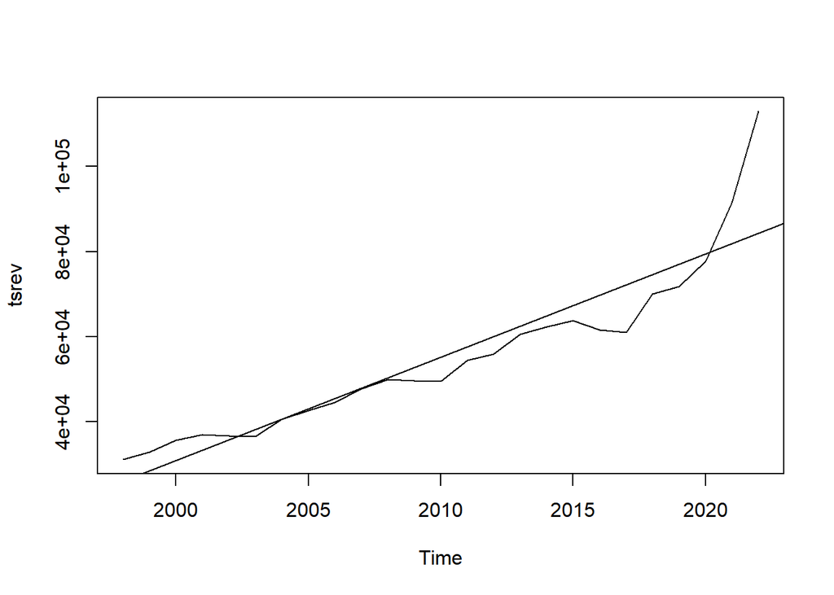

```r
plot(tsrev)
abline(reg=lm(tsrev~time(tsrev)))
```

```r
#### ARIMAs
mymodel <- auto.arima(tsrev, seasonal = FALSE)
mymodel # ARIMA (0, 1, 0) with drift
```

```
## Series: tsrev
## ARIMA(0,2,0)
##
## sigma^2 = 17137060:  log likelihood = -224.19
## AIC=450.38   AICc=450.57   BIC=451.51
```

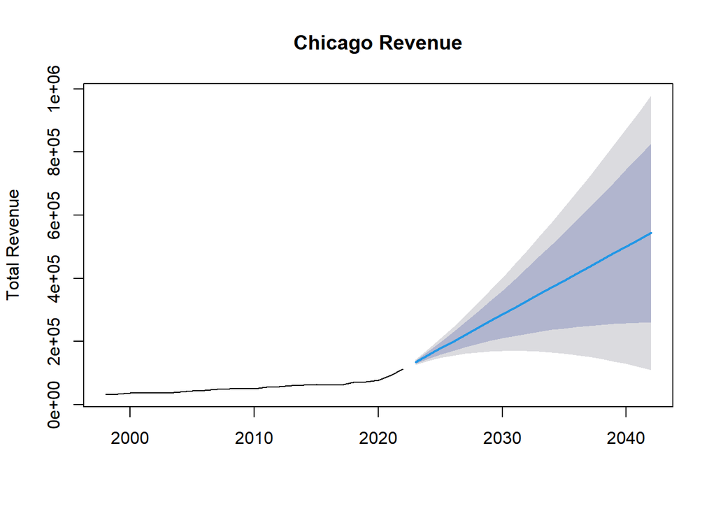

```r
myforecastrev <- forecast(mymodel, h = 20)
plot(myforecastrev,  xlab ="",
     ylab ="Total Revenue",
     main ="Chicago Revenue")
```

```r
tsexp <- ts(year_totals$Expenditures, start = "1998", frequency = 1)
model_exp<- auto.arima(tsexp, seasonal = FALSE)
model_exp # ARIMA (0,1,1) with drift
```

```
## Series: tsexp
## ARIMA(0,1,0) with drift
##
## Coefficients:
##          drift
##       2778.412
## s.e.   800.678
##
## sigma^2 = 16054969:  log likelihood = -232.64
## AIC=469.28   AICc=469.86   BIC=471.64
```

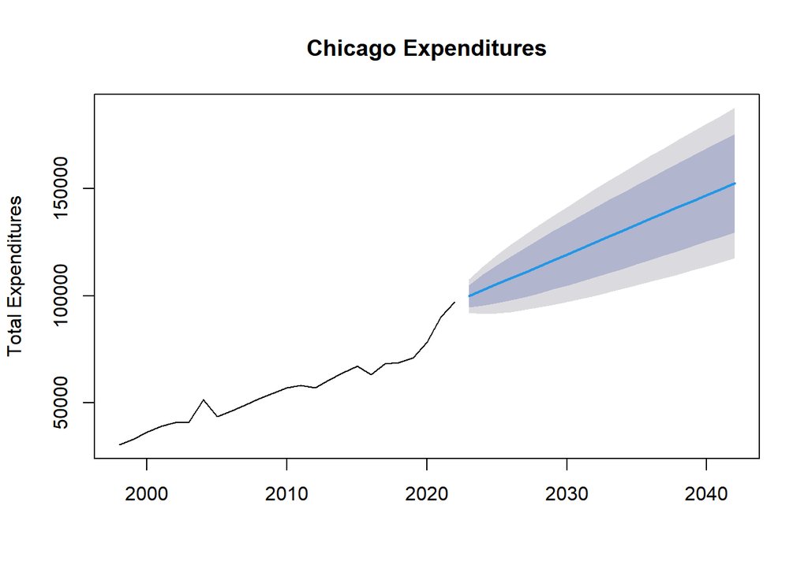

```r
forecast_exp <- forecast(model_exp, h = 20)
plot(forecast_exp, xlab ="",
     ylab ="Total Expenditures",
     main ="Chicago Expenditures")
```